# Методы прикладной статистики

Рябыкин Алексей

## Домашнее задание 2

### Оглавление

#### 1. Задание

#### 2. Установка зависимостей

#### 3. Предварительная обработка

#### 4. Дескриптивный анализ

## Задание

Используйте [набор данных из сборника «Регионы России» Росстата (основные социально-экономические показатели в 2020 г.](https://gks.ru/bgd/regl/b21_14p/Main.htm) или любой другой набор данных. Проведите дескриптивный анализ 5-7 показателей, которые кажутся вам наиболее важными. Под дескриптивным анализом понимается расчет описательных статистик, их интерпретация, построение базовых графиков (гистограммы, диаграммы рассеяния и др.).

## Установка зависимостей

К оглавлению

```r
library(dplyr)
```

```r
library(readxl)
library(ggplot2)
library(docxtractr)
library(tidyr)
library(stringr)
library(skimr)
```

## Предварительная обработка данных

Поменяем названия столбцов, чтобы было легче к ним обращаться.

К оглавлению

```r
data <- read_excel("data.xlsx")
head(data)
```

| ...1 | Площадь территории, тыс. км2 | Численность населения на 1 января 2021 г., тыс. человек | Средне- годовая численность занятых, тыс. человек | Средне- душевые денежные доходы (в месяц), руб. | Потреби- тельские расходы в среднем на душу населения (в месяц), руб. | Средне- месячная номиналь- ная начис- ленная заработная плата работников организаций, руб. | Валовой региональ- ный продукт в 2019 г. , млрд руб. | Инвестиции в основной капитал, млрд руб. | Основные фонды в экономике (по полной учетной стоимости; на конец года), млрд руб. | Объем отгруженных товаров собственного производства, выполненных работ и услуг собственными силами по видам экономической деятельности, млрд руб. | ...12 | ...13 | ...14 | Продукция сельского хозяйства - всего, млрд руб. | в том числе | ...17 | Ввод в действие жилых домов, тыс. м2 общей площади жилых помещений | Оборот розничной торговли, млрд руб. | Сальдированный финансовый результат (прибыль минус убыток) деятельности организаций5), млрд руб. |
| --- | --- | --- | --- | --- | --- | --- | --- | --- | --- | --- | --- | --- | --- | --- | --- | --- | --- | --- | --- |
| NA | NA | NA | NA | NA | NA | NA | NA | NA | NA | добыча \r\nполезных \r\nископаемых | обрабаты-\r\nвающие производства | обеспечение электрической энергией, газом и паром; кондиционирование воздуха | водоснабжение; водоотведение, организация сбора и утилизации отходов, деятельность по ликвидации загрязнений | NA | растение-\r\nводства | животно-\r\nводства | NA | NA | NA |
| Российская Федерация | 17 125,2 | 146 171,0 | 69 550,3 | 36 073 | 27 276 | 51 344 | 94 831,1 | 20 118,4 | 362 191,7 | 14 498,9 | 47 782,6 | 5 960,0 | 1 428,8 | 6 468,8 | 3 612,7 | 2 856,1 | 82 184,5 | 33 873,7 | 13 418,8 |
| Центральный федеральный округ | 650,2 | 39 251,0 | 20 765,6 | 48 226 | 35 117 | 65 319 | 32 937,7 | 6 276,7 | 128 407,4 | 1 443,9 | 17 374,2 | 1 945,4 | 469,6 | 1 810,4 | 1 038,7 | 771,7 | 25 533,3 | 11 849,6 | 5 481,6 |
| NA | NA | NA | NA | NA | NA | NA | NA | NA | NA | NA | NA | NA | NA | NA | NA | NA | NA | NA | NA |
| Белгородская область | 27,1 | 1 541,3 | 751,9 | 32 841 | 26 473 | 37 442 | 956,0 | 168,1 | 2 928,6 | 189,8 | 746,4 | 26,8 | 11,2 | 288,9 | 116,0 | 172,9 | 1 148,6 | 366,3 | 361,3 |
| Брянская область | 34,9 | 1 182,7 | 498,5 | 28 596 | 23 765 | 31 946 | 397,7 | 73,9 | 1 855,1 | 0,3 | 255,7 | 17,9 | 9,6 | 97,3 | 50,9 | 46,4 | 426,7 | 268,0 | 23,2 |

Создадим лист с новыми названиями столбцов и словарь, чтобы восстановить информацию о столбцах.

```r
columns <- c("territory", "square", "population",
             "employees_number", "avg_income",
             "consumer_spending", "avg_normal_wage",
             "gross_product", "investments_base_asset",
             "fixed_economy_assets", "minerals",
             "manufactors", "electricity_energy_gas_couple",
             "water_waste", "agriculture", "crop_prod",
             "animal_husbandry", "residential_buildings",
             "retail_turnover", "net_financial_result"
             )
```

```r
columns_description <- c(
  "territory" = "Место",
  "square" = "Площадь территории, тыс. км2",
  "population" = "Численность населения на 1 января 2021 г., тыс. человек",
  "employees_number" = "Средне-годовая численность занятых, тыс. человек",
  "avg_income" = "Средне-душевые денежные доходы (в месяц), руб.",
  "consumer_spending" = "Потребительские расходы в среднем на душу населения (в месяц), руб.",
  "avg_normal_wage" = "Среднемесячная номинальная начисленная заработная плата работников организаций, руб.",
  "gross_product" = "Валовой региональный продукт в 2019 г., млрд руб.",
  "investments_base_asset" = "Инвестиции в основной капитал, млрд руб.",
  "fixed_economy_assets" = "Основные фонды в экономике (по полной учетной стоимости; на конец года), млрд руб.",
  "minerals" = "добыча полезных ископаемых",
  "manufactors" = "обрабатывающие производства",
  "electricity_energy_gas_couple" = "обеспечение электрической энергией, газом и паром; кондиционирование воздуха",
  "water_waste" = "водоснабжение; водоотведение, организация сбора и утилизации отходов, деятельность по ликвидации загрязнений",
  "agriculture" = "Продукция сельского хозяйства - всего, млрд руб.",
  "crop_prod" = "растениеводства",
  "animal_husbandry" = "животноводства",
  "residential_buildings" = "Ввод в действие жилых домов, тыс. м2 общей площади жилых помещений",
  "retail_turnover" = "Оборот розничной торговли, млрд руб.",
  "net_financial_result" = "Сальдированный финансовый результат (прибыль минус убыток) деятельности организаций,
млрд руб."
)
```

```r
colnames(data) <- columns
head(data)
```

| territory | square | population | employees_number | avg_income | consumer_spending | avg_normal_wage | gross_product | investments_base_asset | fixed_economy_assets | minerals | manufactors | electricity_energy_gas_couple | water_waste | agriculture | crop_prod | animal_husbandry | residential_buildings | retail_turnover | net_financial_result |
| --- | --- | --- | --- | --- | --- | --- | --- | --- | --- | --- | --- | --- | --- | --- | --- | --- | --- | --- | --- |
| NA | NA | NA | NA | NA | NA | NA | NA | NA | NA | добыча \r\nполезных \r\nископаемых | обрабаты-\r\nвающие производства | обеспечение электрической энергией, газом и паром; кондиционирование воздуха | водоснабжение; водоотведение, организация сбора и утилизации отходов, деятельность по ликвидации загрязнений | NA | растение-\r\nводства | животно-\r\nводства | NA | NA | NA |
| Российская Федерация | 17 125,2 | 146 171,0 | 69 550,3 | 36 073 | 27 276 | 51 344 | 94 831,1 | 20 118,4 | 362 191,7 | 14 498,9 | 47 782,6 | 5 960,0 | 1 428,8 | 6 468,8 | 3 612,7 | 2 856,1 | 82 184,5 | 33 873,7 | 13 418,8 |
| Центральный федеральный округ | 650,2 | 39 251,0 | 20 765,6 | 48 226 | 35 117 | 65 319 | 32 937,7 | 6 276,7 | 128 407,4 | 1 443,9 | 17 374,2 | 1 945,4 | 469,6 | 1 810,4 | 1 038,7 | 771,7 | 25 533,3 | 11 849,6 | 5 481,6 |
| NA | NA | NA | NA | NA | NA | NA | NA | NA | NA | NA | NA | NA | NA | NA | NA | NA | NA | NA | NA |
| Белгородская область | 27,1 | 1 541,3 | 751,9 | 32 841 | 26 473 | 37 442 | 956,0 | 168,1 | 2 928,6 | 189,8 | 746,4 | 26,8 | 11,2 | 288,9 | 116,0 | 172,9 | 1 148,6 | 366,3 | 361,3 |
| Брянская область | 34,9 | 1 182,7 | 498,5 | 28 596 | 23 765 | 31 946 | 397,7 | 73,9 | 1 855,1 | 0,3 | 255,7 | 17,9 | 9,6 | 97,3 | 50,9 | 46,4 | 426,7 | 268,0 | 23,2 |

Заметим, что пустые значения связаны с особенностями парсинга из-за слияния ячеек, избавимся от них.

```r
data <- drop_na(data)
head(data)
```

| territory | square | population | employees_number | avg_income | consumer_spending | avg_normal_wage | gross_product | investments_base_asset | fixed_economy_assets | minerals | manufactors | electricity_energy_gas_couple | water_waste | agriculture | crop_prod | animal_husbandry | residential_buildings | retail_turnover | net_financial_result |
| --- | --- | --- | --- | --- | --- | --- | --- | --- | --- | --- | --- | --- | --- | --- | --- | --- | --- | --- | --- |
| Российская Федерация | 17 125,2 | 146 171,0 | 69 550,3 | 36 073 | 27 276 | 51 344 | 94 831,1 | 20 118,4 | 362 191,7 | 14 498,9 | 47 782,6 | 5 960,0 | 1 428,8 | 6 468,8 | 3 612,7 | 2 856,1 | 82 184,5 | 33 873,7 | 13 418,8 |
| Центральный федеральный округ | 650,2 | 39 251,0 | 20 765,6 | 48 226 | 35 117 | 65 319 | 32 937,7 | 6 276,7 | 128 407,4 | 1 443,9 | 17 374,2 | 1 945,4 | 469,6 | 1 810,4 | 1 038,7 | 771,7 | 25 533,3 | 11 849,6 | 5 481,6 |
| Белгородская область | 27,1 | 1 541,3 | 751,9 | 32 841 | 26 473 | 37 442 | 956,0 | 168,1 | 2 928,6 | 189,8 | 746,4 | 26,8 | 11,2 | 288,9 | 116,0 | 172,9 | 1 148,6 | 366,3 | 361,3 |
| Брянская область | 34,9 | 1 182,7 | 498,5 | 28 596 | 23 765 | 31 946 | 397,7 | 73,9 | 1 855,1 | 0,3 | 255,7 | 17,9 | 9,6 | 97,3 | 50,9 | 46,4 | 426,7 | 268,0 | 23,2 |
| Владимирская область | 29,1 | 1 342,1 | 618,6 | 25 922 | 20 653 | 35 240 | 537,4 | 93,4 | 1 993,9 | 5,0 | 526,2 | 37,3 | 12,9 | 32,9 | 14,0 | 18,9 | 726,2 | 239,9 | 59,3 |
| Воронежская область | 52,2 | 2 305,6 | 1 088,1 | 32 078 | 27 110 | 36 317 | 1 002,6 | 258,5 | 4 156,9 | 9,2 | 552,6 | 137,8 | 18,6 | 262,3 | 169,4 | 92,9 | 1 725,8 | 584,3 | 62,5 |

```r
data %>% dim()
```

```
## [1] 96 20
```

Перейдем к декскриптивному анализу

## Дескриптивный анализ

К оглавлению

```r
remove_whitespaces <- function(df, col.names) {
    df[col.names] <- do.call(cbind.data.frame, lapply(df[col.names], function(x) {
      str_remove_all(x, "\\s++")
    }))
    df
}

change_commas <- function(df, col.names) {
    df[col.names] <- do.call(cbind.data.frame, lapply(df[col.names], function(x) {
      str_replace_all(x, ",", ".")
    }))
    df
}

f <- function(df, col.names) {
    df[col.names] <- do.call(cbind.data.frame, lapply(df[col.names], as.numeric))
    df
}
```

```r
cols_to_change <- columns[0:-1]
data <- change_commas(remove_whitespaces(data, cols_to_change), cols_to_change)
```

```r
data <- f(data, cols_to_change)
```

[figure not shown]

[output not shown]

```r
skim(data)
```

Data summary

| Name | data |
| --- | --- |
| Number of rows | 96 |
| Number of columns | 20 |
| _______________________ |  |
| Column type frequency: |  |
| character | 1 |
| numeric | 19 |
| ________________________ |  |
| Group variables | None |

**Variable type: character**

| skim_variable | n_missing | complete_rate | min | max | empty | n_unique | whitespace |
| --- | --- | --- | --- | --- | --- | --- | --- |
| territory | 0 | 1 | 9 | 41 | 0 | 95 | 0 |

**Variable type: numeric**

| skim_variable | n_missing | complete_rate | mean | sd | p0 | p25 | p50 | p75 | p100 | hist |
| --- | --- | --- | --- | --- | --- | --- | --- | --- | --- | --- |
| square | 0 | 1.00 | 556.56 | 1948.97 | 0.9 | 35.88 | 85.65 | 323.62 | 17125.2 | ▇▁▁▁▁ |
| population | 0 | 1.00 | 4618.94 | 15667.08 | 44.4 | 781.18 | 1243.50 | 2787.55 | 146171.0 | ▇▁▁▁▁ |
| employees_number | 0 | 1.00 | 2201.50 | 7512.14 | 31.2 | 358.65 | 554.05 | 1171.85 | 69550.3 | ▇▁▁▁▁ |
| avg_income | 0 | 1.00 | 33386.81 | 14301.66 | 16877.0 | 25374.50 | 29449.50 | 35744.50 | 89928.0 | ▇▃▁▁▁ |
| consumer_spending | 0 | 1.00 | 24148.24 | 6849.74 | 9421.0 | 19909.75 | 22633.00 | 27452.50 | 51704.0 | ▂▇▃▁▁ |
| avg_normal_wage | 0 | 1.00 | 46131.33 | 19302.84 | 29083.0 | 33454.25 | 38618.50 | 51383.25 | 120641.0 | ▇▂▁▁▁ |
| gross_product | 0 | 1.00 | 3065.65 | 10488.98 | 56.6 | 315.35 | 626.45 | 1545.62 | 94831.1 | ▇▁▁▁▁ |
| investments_base_asset | 0 | 1.00 | 653.65 | 2200.56 | 13.3 | 61.40 | 153.75 | 328.70 | 20118.4 | ▇▁▁▁▁ |
| fixed_economy_assets | 0 | 1.00 | 11718.23 | 40044.47 | 189.0 | 1218.93 | 2541.70 | 5821.85 | 362191.7 | ▇▁▁▁▁ |
| minerals | 4 | 0.96 | 531.79 | 1737.35 | 0.1 | 2.40 | 29.10 | 259.72 | 14498.9 | ▇▁▁▁▁ |
| manufactors | 0 | 1.00 | 1511.83 | 5291.30 | 0.6 | 123.30 | 309.00 | 854.38 | 47782.6 | ▇▁▁▁▁ |
| electricity_energy_gas_couple | 0 | 1.00 | 190.10 | 650.57 | 0.4 | 22.15 | 45.45 | 124.32 | 5960.0 | ▇▁▁▁▁ |
| water_waste | 4 | 0.96 | 47.20 | 159.74 | 0.4 | 4.30 | 10.05 | 25.15 | 1428.8 | ▇▁▁▁▁ |
| agriculture | 1 | 0.99 | 205.32 | 704.73 | 0.8 | 24.45 | 54.40 | 135.40 | 6468.8 | ▇▁▁▁▁ |
| crop_prod | 1 | 0.99 | 114.48 | 397.52 | 0.1 | 7.60 | 27.00 | 82.10 | 3612.7 | ▇▁▁▁▁ |
| animal_husbandry | 1 | 0.99 | 90.84 | 309.34 | 0.2 | 13.45 | 30.20 | 55.30 | 2856.1 | ▇▁▁▁▁ |
| residential_buildings | 0 | 1.00 | 2600.30 | 8921.11 | 1.7 | 292.55 | 691.25 | 1419.93 | 82184.5 | ▇▁▁▁▁ |
| retail_turnover | 0 | 1.00 | 1071.81 | 3711.37 | 10.0 | 159.50 | 247.60 | 556.70 | 33873.7 | ▇▁▁▁▁ |
| net_financial_result | 0 | 1.00 | 429.94 | 1556.52 | -40.5 | 13.15 | 51.40 | 148.85 | 13418.8 | ▇▁▁▁▁ |

Посмотрим на потребительские расходы

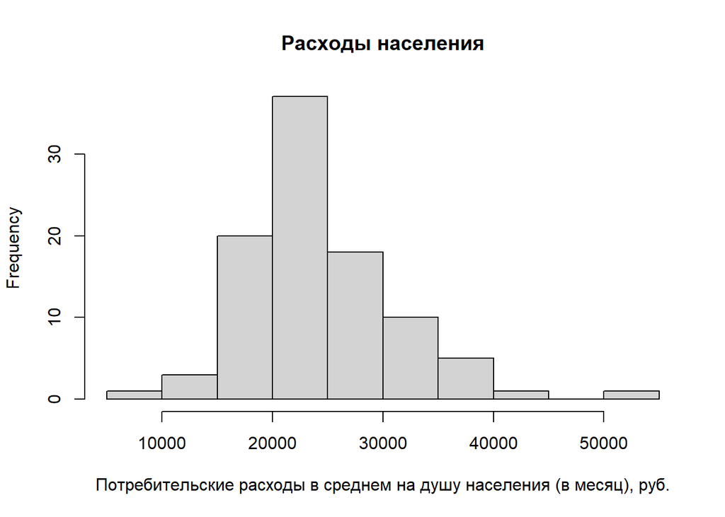

```r
hist(data$consumer_spending,
     xlab=columns_description["consumer_spending"],
     main="Расходы населения")
```

```r
columns
```

```
##  [1] "territory"                     "square"
##  [3] "population"                    "employees_number"
##  [5] "avg_income"                    "consumer_spending"
##  [7] "avg_normal_wage"               "gross_product"
##  [9] "investments_base_asset"        "fixed_economy_assets"
## [11] "minerals"                      "manufactors"
## [13] "electricity_energy_gas_couple" "water_waste"
## [15] "agriculture"                   "crop_prod"
## [17] "animal_husbandry"              "residential_buildings"
## [19] "retail_turnover"               "net_financial_result"
```

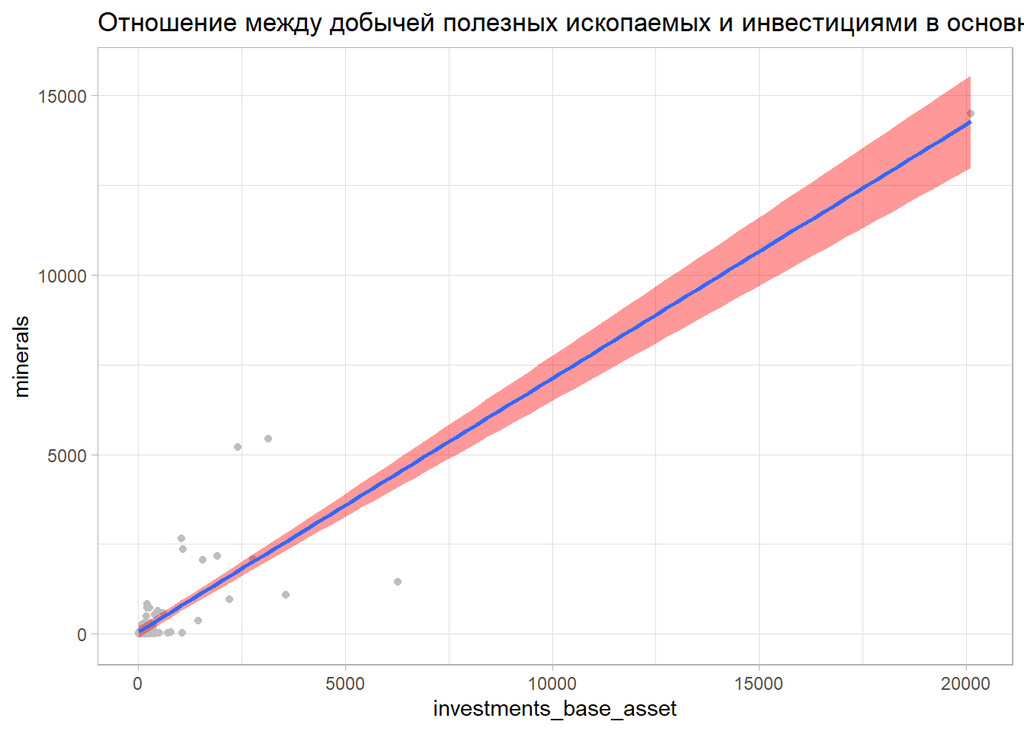

```r
ggplot(data, aes(x = investments_base_asset, y = minerals)) +
  geom_jitter(color = "grey", alpha = 5) +
  geom_smooth(method = "lm", fill = "red") +
  ggtitle("Отношение между добычей полезных ископаемых и инвестициями в основной капитал") +
  theme_light()
```

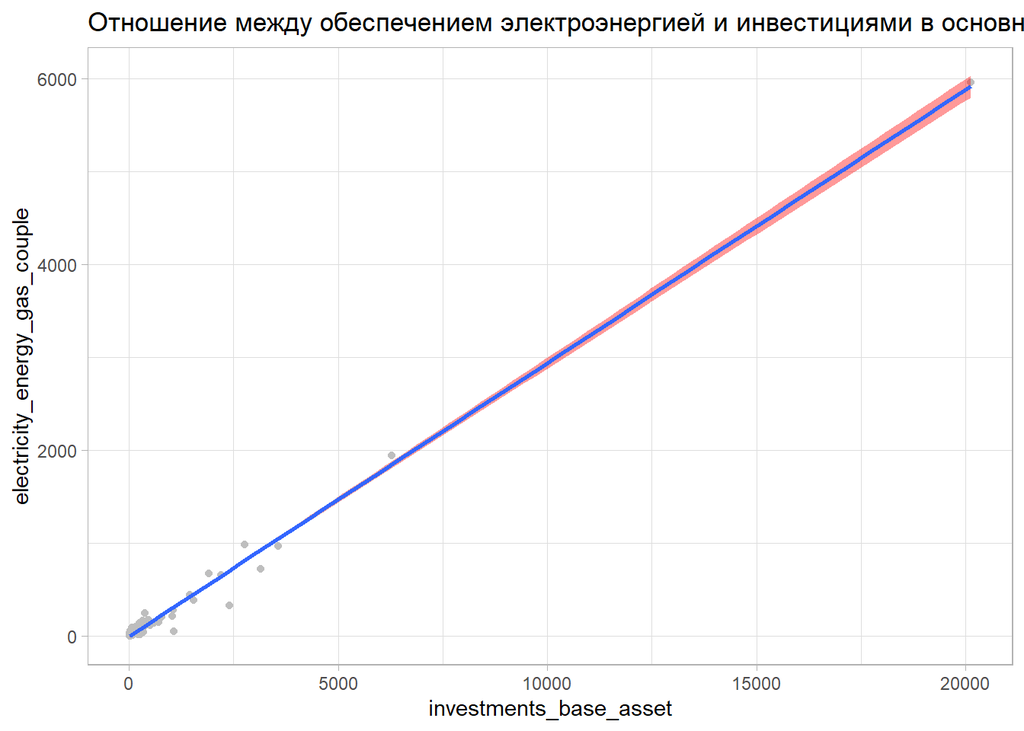

```r
ggplot(data, aes(x = investments_base_asset, y = electricity_energy_gas_couple)) +
  geom_jitter(color = "grey", alpha = 5) +
  geom_smooth(method = "lm", fill = "red") +
  ggtitle("Отношение между обеспечением электроэнергией и инвестициями в основной капитал") +
  theme_light()
```

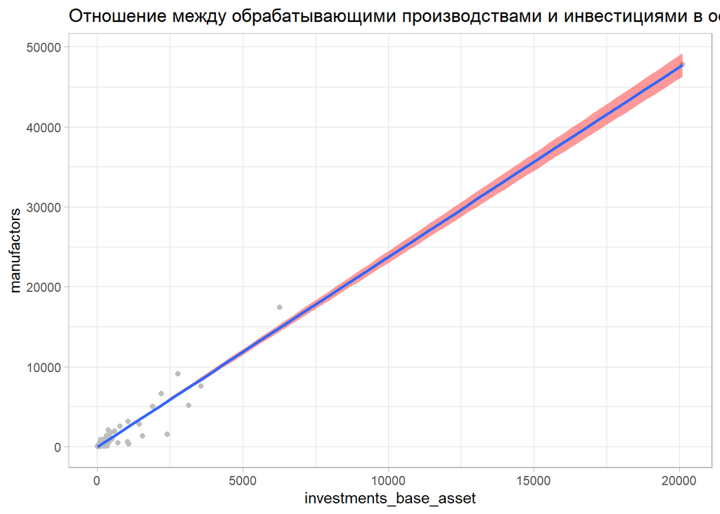

```r
ggplot(data, aes(x = investments_base_asset, y = manufactors)) +
  geom_jitter(color = "grey", alpha = 5) +
  geom_smooth(method = "lm", fill = "red") +
  ggtitle("Отношение между обрабатывающими производствами и инвестициями в основной капитал") +
  theme_light()
```

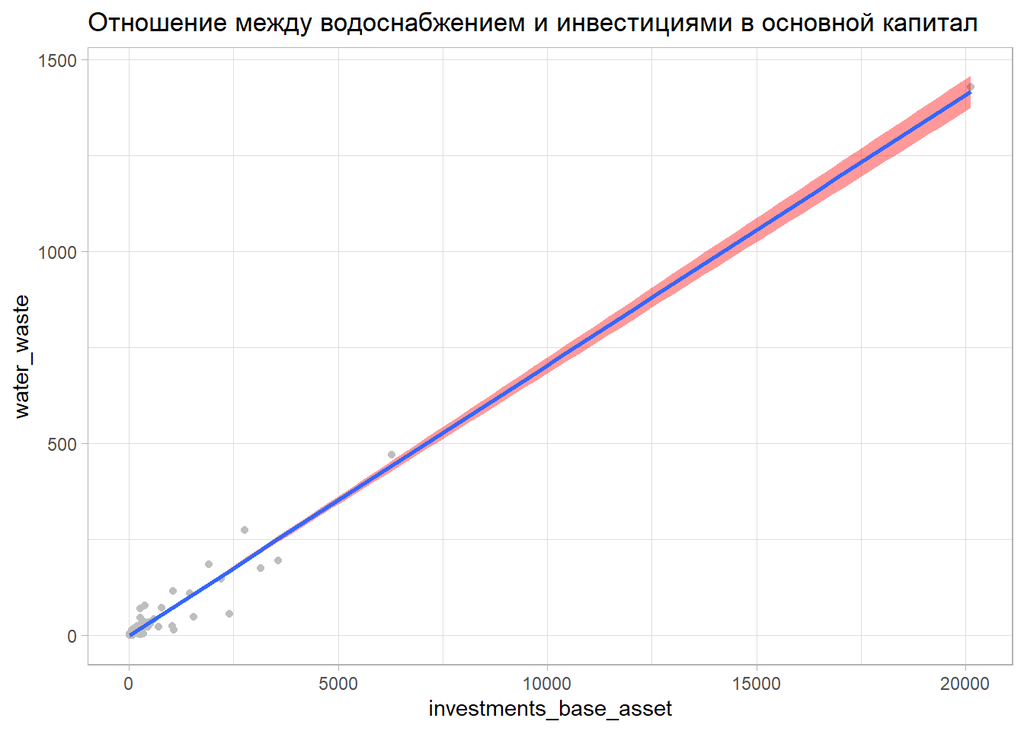

```r
ggplot(data, aes(x = investments_base_asset, y = water_waste)) +
  geom_jitter(color = "grey", alpha = 5) +
  geom_smooth(method = "lm", fill = "red") +
  ggtitle("Отношение между водоснабжением и инвестициями в основной капитал") +
  theme_light()
```

```r
# to_ignore = c("Российская Федерация", "Центральный федеральный округ",
 #             "Приволжский федеральный округ",
#              "Северо-Западный федеральный округ",
  #            "Уральский федеральный округ",
   #           "Сибирский федеральный округ",
    #          "Южный федеральный округ")
data[order(data$manufactors, decreasing = T), ][c("territory", "manufactors")]
```

| territory | manufactors |
| --- | --- |
| Российская Федерация | 47782.6 |
| Центральный федеральный округ | 17374.2 |
| Приволжский федеральный округ | 9093.3 |
| г. Москва | 7529.1 |
| Северо-Западный федеральный округ | 6617.3 |
| Уральский федеральный округ | 5134.9 |
| Сибирский федеральный округ | 4982.6 |
| Московская область | 3116.6 |
| Южный федеральный округ | 2788.4 |
| г. Санкт-Петербург | 2564.8 |

[output cut: 86 more lines]

```r
data[order(data$minerals, decreasing = T), ][c("territory", "minerals")]
```

| territory | minerals |
| --- | --- |
| Российская Федерация | 14498.9 |
| Уральский федеральный округ | 5435.8 |
| Тюменская область | 5200.2 |
| Ханты-Мансийский автономный округ -- Югра | 2659.1 |
| Ямало-Ненецкий автономный округ | 2357.9 |
| Сибирский федеральный округ | 2159.7 |
| Приволжский федеральный округ | 2074.2 |
| Дальневосточный федеральный округ | 2053.7 |
| Центральный федеральный округ | 1443.9 |
| г. Москва | 1092.7 |

[output cut: 86 more lines]

```r
data[order(data$investments_base_asset, decreasing = T), ][c("territory", "investments_base_asset")]
```

| territory | investments_base_asset |
| --- | --- |
| Российская Федерация | 20118.4 |
| Центральный федеральный округ | 6276.7 |
| г. Москва | 3567.6 |
| Уральский федеральный округ | 3146.9 |
| Приволжский федеральный округ | 2763.7 |
| Тюменская область | 2403.6 |
| Северо-Западный федеральный округ | 2204.7 |
| Сибирский федеральный округ | 1913.7 |
| Дальневосточный федеральный округ | 1551.1 |
| Южный федеральный округ | 1450.2 |

[output cut: 86 more lines]

Посмотрим, есть ли зависимость между численностью населения и вводом жилых домой, чтобы понять, насколько предложение соответствует запросам.

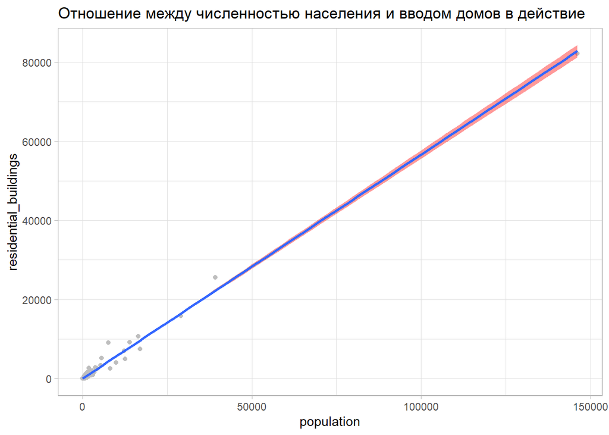

```r
ggplot(data, aes(x = population, y = residential_buildings)) +
  geom_jitter(color = "grey", alpha = 5) +
  geom_smooth(method = "lm", fill = "red") +
  ggtitle("Отношение между численностью населения и вводом домов в действие") +
  theme_light()
```

Так же отмечается линейный тренд.

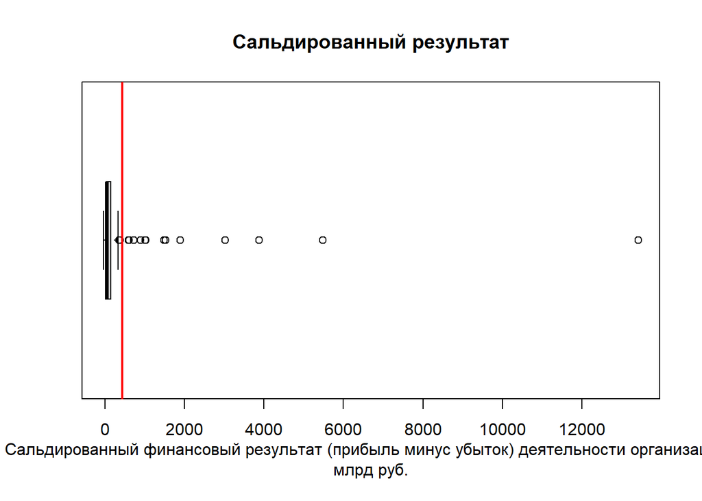

```r
boxplot(data$net_financial_result, horizontal = T,
        xlab = columns_description["net_financial_result"],
        main = "Сальдированный результат",
        adj = 0,
        col = "light grey")
abline(v = mean(data$net_financial_result), col = "red", lwd = 2)
```

Здесь виден явный скос выборки, говорит о том, что финансовая успешность предприятий находится в территориальной зависимости. Отсортируем

```r
data[order(data$net_financial_result, decreasing = T), ][c("territory", "net_financial_result")]
```

| territory | net_financial_result |
| --- | --- |
| Российская Федерация | 13418.8 |
| Центральный федеральный округ | 5481.6 |
| г. Москва | 3881.9 |
| Северо-Западный федеральный округ | 3029.8 |
| г. Санкт-Петербург | 1899.0 |
| Сибирский федеральный округ | 1524.1 |
| Уральский федеральный округ | 1480.4 |
| Красноярский край | 1031.4 |
| Тюменская область | 1017.7 |
| Ханты-Мансийский автономный округ -- Югра | 893.9 |

[output cut: 86 more lines]

Сальдированный финансовый результат, в целом, сильно распластался по всей России, однако, видно, что в каждом федеральном образовании есть невыгодные земли для развития предприятий.